# Logistic regression

The data includes students’ secondary education accomplishment of two portuguese schools. The data attributes include student grades, demographic, social and school related features’) and it was collected by using school reports and questionnaires. Two datasets are provided regarding the performance in two distinct subjects: Mathematics (mat) and Portuguese language (por). In [Cortez and Silva, 2008], the two datasets were modeled under binary/five-level classification and regression tasks. Important note: the target attribute G3 has a strong correlation with attributes G2 and G1. This occurs because G3 is the final year grade (issued at the 3rd period), while G1 and G2 correspond to the 1st and 2nd period grades. It is more difficult to predict G3 without G2 and G1, but such prediction is much more useful (see paper source for more details). [This is the data source](https://archive.ics.uci.edu/ml/datasets/Student+Performance)

### Data Set Information:

Data was gotten from this [source](http://s3.amazonaws.com/assets.datacamp.com/production/course_2218/datasets/alc.txt)

```r
# access the tidyverse libraries tidyr, dplyr, ggplot2
#install.packages("tidyr")
library(tidyr); library(dplyr); library(ggplot2); library(GGally);

#read the data
alc<- read.table("http://s3.amazonaws.com/assets.datacamp.com/production/course_2218/datasets/alc.txt", sep = ",", header = T)
```

### DATA OVERVIEW

```r
colnames(alc)   #names of columns
```

```
##  [1] "school"     "sex"        "age"        "address"    "famsize"
##  [6] "Pstatus"    "Medu"       "Fedu"       "Mjob"       "Fjob"
## [11] "reason"     "nursery"    "internet"   "guardian"   "traveltime"
## [16] "studytime"  "failures"   "schoolsup"  "famsup"     "paid"
## [21] "activities" "higher"     "romantic"   "famrel"     "freetime"
## [26] "goout"      "Dalc"       "Walc"       "health"     "absences"
## [31] "G1"         "G2"         "G3"         "alc_use"    "high_use"
```

```r
summary(alc)    #summary
```

```
##  school   sex          age        address famsize   Pstatus
##  GP:342   F:198   Min.   :15.00   R: 81   GT3:278   A: 38
##  MS: 40   M:184   1st Qu.:16.00   U:301   LE3:104   T:344
##                   Median :17.00
##                   Mean   :16.59
##                   3rd Qu.:17.00
##                   Max.   :22.00
##       Medu            Fedu             Mjob           Fjob
##  Min.   :0.000   Min.   :0.000   at_home : 53   at_home : 16
##  1st Qu.:2.000   1st Qu.:2.000   health  : 33   health  : 17
##  Median :3.000   Median :3.000   other   :138   other   :211
##  Mean   :2.806   Mean   :2.565   services: 96   services:107
##  3rd Qu.:4.000   3rd Qu.:4.000   teacher : 62   teacher : 31
##  Max.   :4.000   Max.   :4.000
##         reason    nursery   internet    guardian     traveltime
##  course    :140   no : 72   no : 58   father: 91   Min.   :1.000
##  home      :110   yes:310   yes:324   mother:275   1st Qu.:1.000
##  other     : 34                       other : 16   Median :1.000
##  reputation: 98                                    Mean   :1.442
##                                                    3rd Qu.:2.000
##                                                    Max.   :4.000
##    studytime        failures      schoolsup famsup     paid     activities
##  Min.   :1.000   Min.   :0.0000   no :331   no :144   no :205   no :181
##  1st Qu.:1.000   1st Qu.:0.0000   yes: 51   yes:238   yes:177   yes:201
##  Median :2.000   Median :0.0000
##  Mean   :2.034   Mean   :0.2906
##  3rd Qu.:2.000   3rd Qu.:0.0000
##  Max.   :4.000   Max.   :3.0000
##  higher    romantic      famrel        freetime         goout
##  no : 18   no :261   Min.   :1.00   Min.   :1.000   Min.   :1.000
##  yes:364   yes:121   1st Qu.:4.00   1st Qu.:3.000   1st Qu.:2.000
##                      Median :4.00   Median :3.000   Median :3.000
##                      Mean   :3.94   Mean   :3.223   Mean   :3.113
##                      3rd Qu.:5.00   3rd Qu.:4.000   3rd Qu.:4.000
##                      Max.   :5.00   Max.   :5.000   Max.   :5.000
##       Dalc            Walc          health         absences
##  Min.   :1.000   Min.   :1.00   Min.   :1.000   Min.   : 0.000
##  1st Qu.:1.000   1st Qu.:1.00   1st Qu.:3.000   1st Qu.: 0.000
##  Median :1.000   Median :2.00   Median :4.000   Median : 3.000
##  Mean   :1.474   Mean   :2.28   Mean   :3.579   Mean   : 5.319
##  3rd Qu.:2.000   3rd Qu.:3.00   3rd Qu.:5.000   3rd Qu.: 8.000
##  Max.   :5.000   Max.   :5.00   Max.   :5.000   Max.   :75.000
##        G1              G2              G3           alc_use
##  Min.   : 3.00   Min.   : 0.00   Min.   : 0.00   Min.   :1.000
##  1st Qu.: 8.00   1st Qu.: 8.25   1st Qu.: 8.00   1st Qu.:1.000
##  Median :10.50   Median :11.00   Median :11.00   Median :1.500
##  Mean   :10.86   Mean   :10.71   Mean   :10.39   Mean   :1.877
##  3rd Qu.:13.00   3rd Qu.:13.00   3rd Qu.:14.00   3rd Qu.:2.500
##  Max.   :19.00   Max.   :19.00   Max.   :20.00   Max.   :5.000
##   high_use
##  Mode :logical
##  FALSE:270
##  TRUE :112
##
##
##
```

```r
dim(alc)    #dimension
```

```
## [1] 382  35
```

```r
str(alc)   #structure
```

```
## 'data.frame':    382 obs. of  35 variables:
##  $ school    : Factor w/ 2 levels "GP","MS": 1 1 1 1 1 1 1 1 1 1 ...
##  $ sex       : Factor w/ 2 levels "F","M": 1 1 1 1 1 2 2 1 2 2 ...
##  $ age       : int  18 17 15 15 16 16 16 17 15 15 ...
##  $ address   : Factor w/ 2 levels "R","U": 2 2 2 2 2 2 2 2 2 2 ...
##  $ famsize   : Factor w/ 2 levels "GT3","LE3": 1 1 2 1 1 2 2 1 2 1 ...
##  $ Pstatus   : Factor w/ 2 levels "A","T": 1 2 2 2 2 2 2 1 1 2 ...
##  $ Medu      : int  4 1 1 4 3 4 2 4 3 3 ...
##  $ Fedu      : int  4 1 1 2 3 3 2 4 2 4 ...
##  $ Mjob      : Factor w/ 5 levels "at_home","health",..: 1 1 1 2 3 4 3 3 4 3 ...
##  $ Fjob      : Factor w/ 5 levels "at_home","health",..: 5 3 3 4 3 3 3 5 3 3 ...
##  $ reason    : Factor w/ 4 levels "course","home",..: 1 1 3 2 2 4 2 2 2 2 ...
##  $ nursery   : Factor w/ 2 levels "no","yes": 2 1 2 2 2 2 2 2 2 2 ...
##  $ internet  : Factor w/ 2 levels "no","yes": 1 2 2 2 1 2 2 1 2 2 ...
##  $ guardian  : Factor w/ 3 levels "father","mother",..: 2 1 2 2 1 2 2 2 2 2 ...
```

[output cut: 21 more lines]

```r
attach(alc)   #attach all the variables in the dataframe
# define a new logical column 'high_use'
alc$high_use<- alc$alc_use > 2
#alc <- mutate(alc, high_use = alc_use > 2) #alternative
```

### Hypotheses.

- *age is not related to alcohol consumption*
- *sex is not related to alcohol consumption*
- *absence from school is not related to alcóhol use*
- *freetime after school is not related to alcohol consumption*

## subsetting and exploring my chosen variables

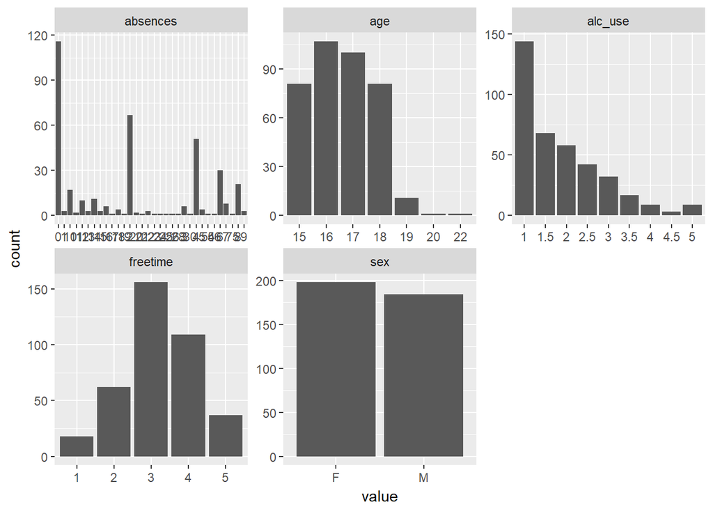

```r
hyp<- alc[,c("age", "sex",  "absences","freetime","alc_use")]
#exploring my chosen variables
# draw a bar plot of each variable
hyp<-gather(hyp) %>% ggplot(aes(value)) + facet_wrap("key", scales = "free")
hyp + geom_bar()
```

The above shows the distribution of the chosen predictors and also scale of alcohol consumption. The ages of the students are mainly within 15-19 with few students aged 20 and 22. Generally, there are relatively few chronic alcohol consumers amongst the students. The students seem to have quite enough free time. The respondents include 198 female students and 184 male students.

## Overview of the chosen predictors and alcohol consumption variable.

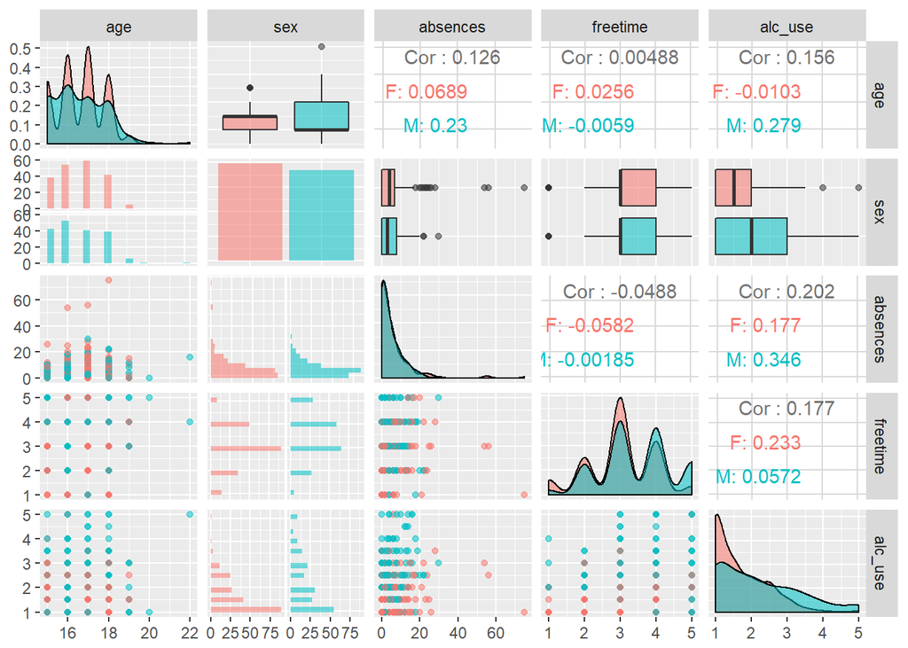

```r
hyp<- alc[,c("age", "sex",  "absences","freetime","alc_use")]
#show the overview of the predictors and response variable(non-binomial)
plot_hyp <- ggpairs(hyp, mapping = aes(col=sex, alpha=0.3), lower = list(combo = wrap("facethist", bins = 20)))
plot_hyp   #draw the plot
```

Here, we can see that the female students seem to be generally quite older and there are both male and female students that are much older than the general sample of the students. The absences are not so high but some chronic absentees amongst the students(both male and female). Most of the students are quite free but a few of the students are very busy. Largely, all the predictors show no correlation, hence, the issue of multicolinearity is not a problem here. However, these predictors still show very weak correlation with alcohol consumption. Nevertheless, it should be recalled that correlation is not causation. Hence, I will dig further to understand the effects of these predictors on alcohol consumption amongst students and see if they are significant.

## Crosstabs

**The below are crosstabs that compare the predictors with alcohol consumption**

```r
#using the binomial response(high_use)
#it is also possible to use simple crosstabs e.g
#xtabs(high_use~age, data = alc)
#but below is a more comprehensive crosstab.
#Crosstabs
summarise(group_by(alc, age,high_use), count=n(), mean_grade=mean(G3))
```

```
## # A tibble: 12 x 4
## # Groups:   age [?]
##      age high_use count mean_grade
##    <int>    <lgl> <int>      <dbl>
##  1    15    FALSE    63  11.380952
##  2    15     TRUE    18  11.055556
##  3    16    FALSE    79  11.303797
##  4    16     TRUE    28  10.714286
##  5    17    FALSE    65  10.123077
##  6    17     TRUE    35  10.228571
##  7    18    FALSE    55   9.218182
##  8    18     TRUE    26   9.423077
##  9    19    FALSE     7   5.714286
## 10    19     TRUE     4   6.250000
## 11    20    FALSE     1  18.000000
## 12    22     TRUE     1   8.000000
```

```r
#an alternative and preferrable way of doing the above
#alc %>% group_by(age, high_use) %>% summarise(count=n(), mean_grade =  mean(G3))

summarise(group_by(alc, sex,high_use), count=n(), mean_grade=mean(G3))
```

```
## # A tibble: 4 x 4
## # Groups:   sex [?]
##      sex high_use count mean_grade
##   <fctr>    <lgl> <int>      <dbl>
## 1      F    FALSE   157   9.687898
## 2      F     TRUE    41  10.414634
## 3      M    FALSE   113  11.610619
## 4      M     TRUE    71   9.971831
```

```r
summarise(group_by(alc, absences,high_use), count=n(), mean_grade=mean(G3))
```

```
## # A tibble: 48 x 4
## # Groups:   absences [?]
##    absences high_use count mean_grade
##       <int>    <lgl> <int>      <dbl>
##  1        0    FALSE    94   8.372340
##  2        0     TRUE    22   8.318182
##  3        1    FALSE     2  12.000000
##  4        1     TRUE     1  15.000000
##  5        2    FALSE    54  12.296296
##  6        2     TRUE    13  11.076923
##  7        3    FALSE     2  11.000000
##  8        3     TRUE     4  13.000000
##  9        4    FALSE    36  11.666667
## 10        4     TRUE    15  10.200000
## # ... with 38 more rows
```

```r
summarise(group_by(alc, freetime,high_use), count=n(), mean_grade=mean(G3))
```

```
## # A tibble: 10 x 4
## # Groups:   freetime [?]
##    freetime high_use count mean_grade
##       <int>    <lgl> <int>      <dbl>
##  1        1    FALSE    16    9.12500
##  2        1     TRUE     2    8.50000
##  3        2    FALSE    47   11.87234
##  4        2     TRUE    15   11.60000
##  5        3    FALSE   116    9.75000
##  6        3     TRUE    40    9.82500
##  7        4    FALSE    69   10.46377
##  8        4     TRUE    40   10.10000
##  9        5    FALSE    22   12.54545
## 10        5     TRUE    15    9.80000
```

## Bar chats

### The age distribution by sex

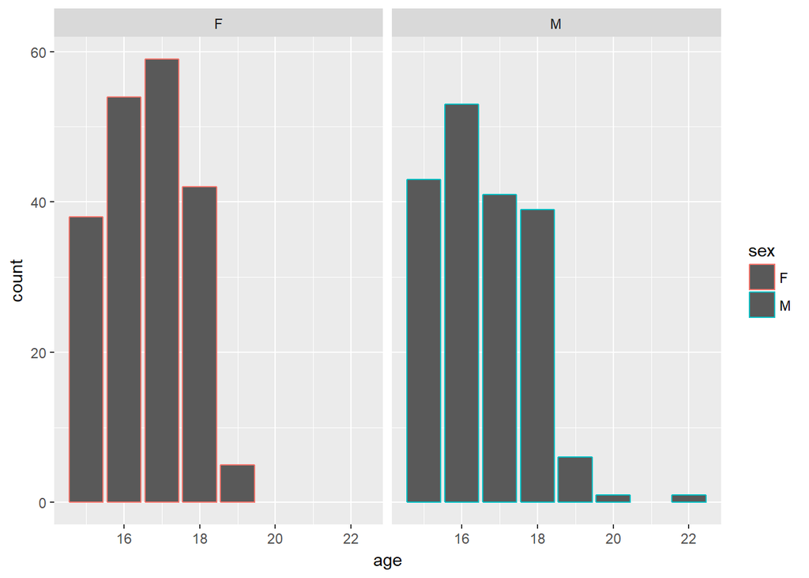

```r
# initialize a plot of 'age'
sex_age <- ggplot(data = alc, aes(x=age, col=sex))

# draw a bar plot of age by sex
sex_age + geom_bar() + facet_wrap("sex")
```

### high alcohol consumption by sex

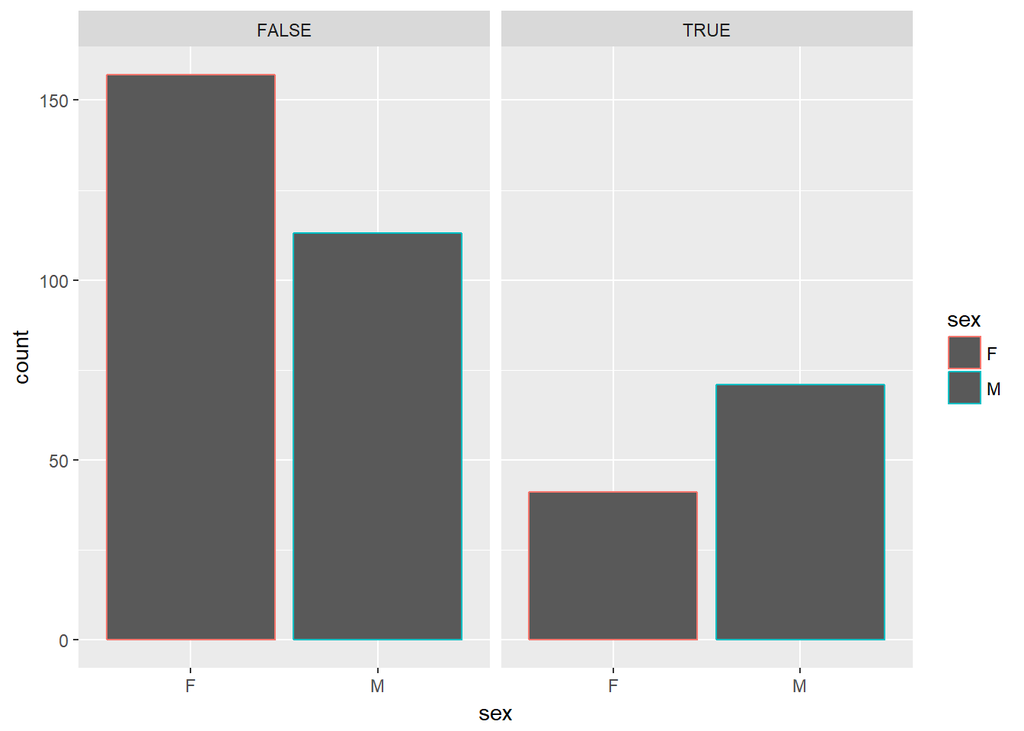

```r
# initialize a plot of 'high_use'
hu_sex <- ggplot(data = alc, aes(x=sex, col=sex))

# draw a bar plot of high_use by sex
hu_sex + geom_bar() + facet_wrap("high_use")
```

Here, we can see that there are more female who do are not high consumers of alcohol compared to men. Men consume more alchols than their female counterparts.

### High use vs freetime

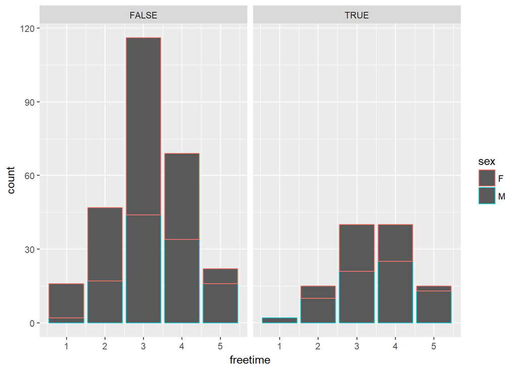

```r
# initialize a plot of 'high_use'
hu_ft <- ggplot(data = alc, aes(x=freetime, col=sex))

# draw a bar plot of 'high_use' by freetime
hu_ft + geom_bar() + facet_wrap("high_use")
```

Most students with more freetime seem not to consume alcohol as one would expect

### High use vs absences

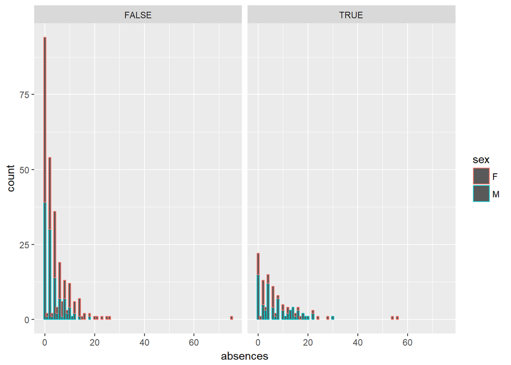

```r
# initialize a plot of 'high_use'
hu_ab <- ggplot(data = alc, aes(x=absences, col=sex))

# draw a bar plot of 'high_use' by freetime
hu_ab + geom_bar() + facet_wrap("high_use")
```

```r
#few of the absentees are alcoholic but many are not.
```

### High use vs age

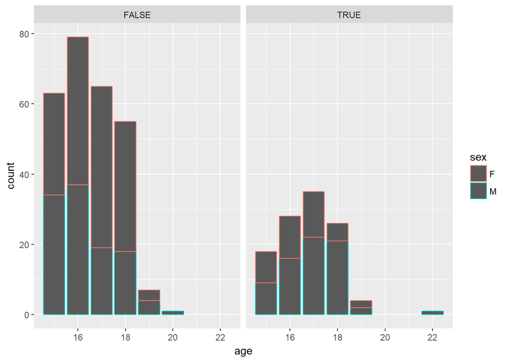

```r
# initialize a plot of 'high_use'
hu_ag <- ggplot(data = alc, aes(x=age, col=sex))

# draw a bar plot of 'high_use' by freetime
hu_ag + geom_bar() + facet_wrap("high_use")
```

some of the young students below 20 years are high consumers of alcohol, but less so of those that are not high alchol consumers.

### High use vs romantic

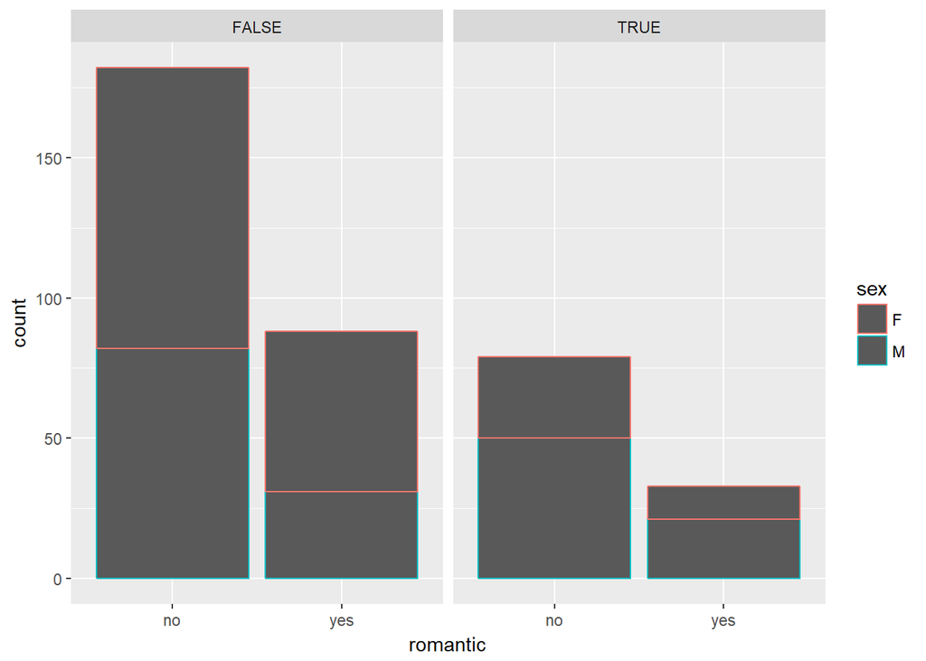

```r
# initialize a plot of 'high_use'
hu_rom <- ggplot(data = alc, aes(x=romantic, col=sex))

# draw a bar plot of 'high_use' by freetime
hu_rom + geom_bar() + facet_wrap("high_use")
```

For students in romantic relationships, they generally have lower number of them that are high consumers of alcohol. This is same with those in no romatic relationships.

## BOXPLOTS

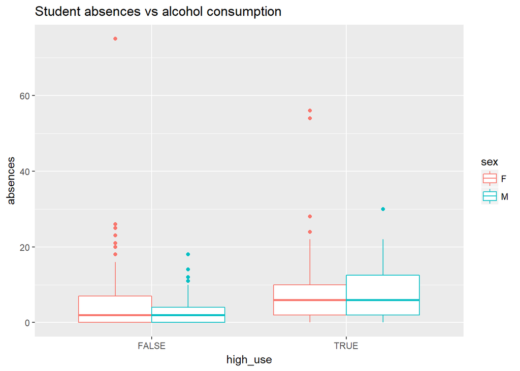

```r
# initialise a plot of high_use and absences
h_ab<- ggplot(alc, aes(x=high_use, y=absences,col=sex))

# define the plot as a boxplot and draw it
h_ab + geom_boxplot() + ggtitle("Student absences vs alcohol consumption")
```

There are a few chronic absentees amongst male and female students, but generally, most of the students have low absences.

### Relationship of alcohol consumption with age

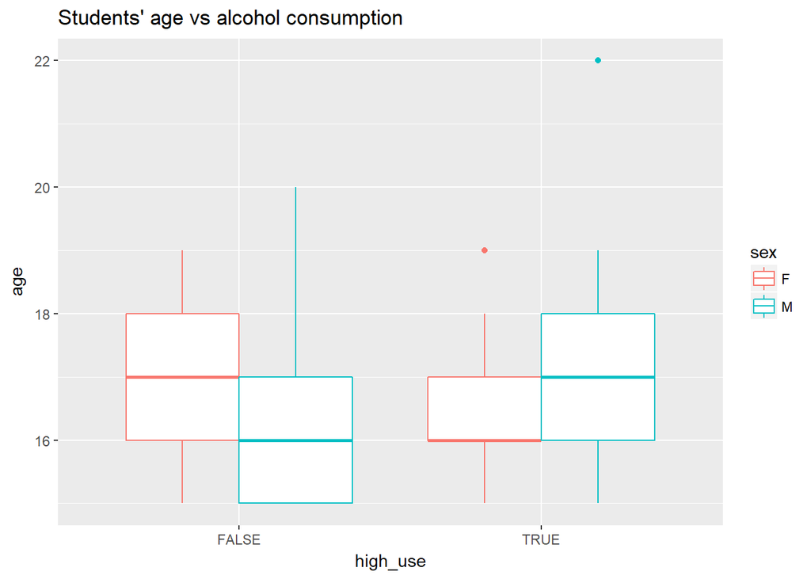

```r
# initialise a plot of high_use and age
h_ag<- ggplot(alc, aes(x=high_use, y=age,col=sex))

# define the plot as a boxplot and draw it
h_ag + geom_boxplot() + ggtitle("Students' age vs alcohol consumption")
```

### Relationship of alcohol consumption with freetime

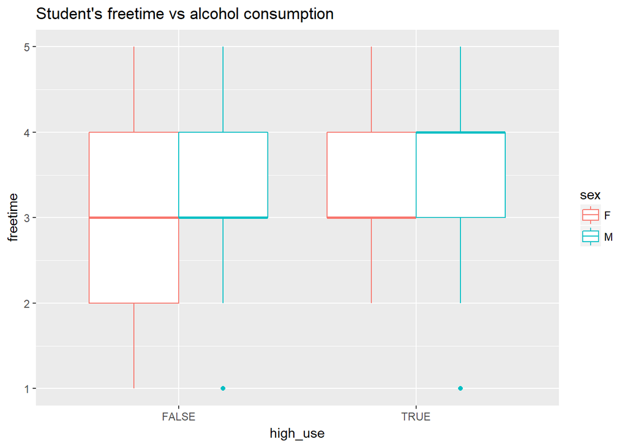

```r
# initialise a plot of high_use and freetime
h_fr<- ggplot(alc, aes(x=high_use, y=freetime,col=sex))

# define the plot as a boxplot and draw it
h_fr + geom_boxplot() + ggtitle("Student's freetime vs alcohol consumption")
```

### Relationship of alcohol consumption with sex

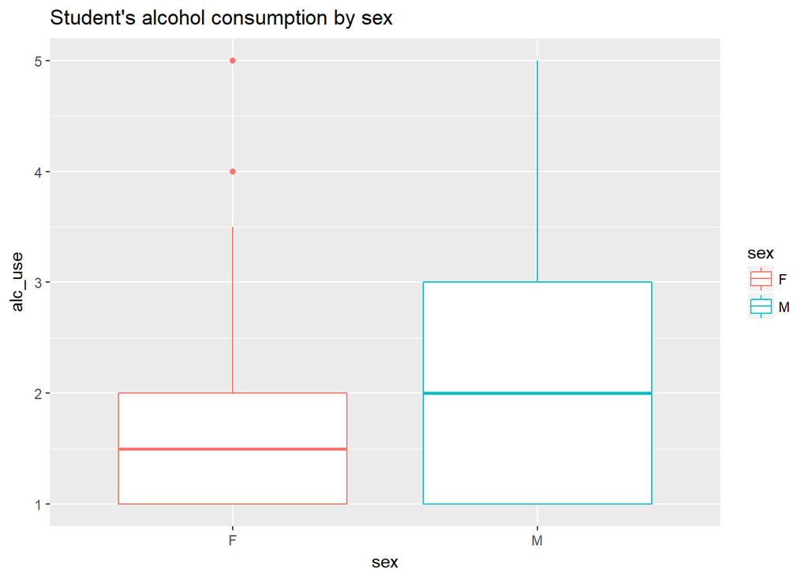

```r
# initialise a plot of high_use and sex
alc_sex<- ggplot(alc, aes(y=alc_use, x=sex,col=sex))

# define the plot as a boxplot and draw it
alc_sex + geom_boxplot() + ggtitle("Student's alcohol consumption by sex")
```

There are a few female students with quite high alcohol consumption but the alcohol consumption levels do not vary as much as they do amongst the male students.

## Logistic regression

### fitting the glm model

```r
high_use_mod1<- glm(high_use~ age + sex + absences + freetime , data= alc, family = "binomial")
summary(high_use_mod1)
```

```
##
## Call:
## glm(formula = high_use ~ age + sex + absences + freetime, family = "binomial",
##     data = alc)
##
## Deviance Residuals:
##     Min       1Q   Median       3Q      Max
## -2.5188  -0.8214  -0.5957   1.0480   2.1082
##
## Coefficients:
##             Estimate Std. Error z value Pr(>|z|)
## (Intercept) -5.35260    1.76384  -3.035 0.002408 **
## age          0.15609    0.10221   1.527 0.126698
## sexM         0.89550    0.24773   3.615 0.000301 ***
## absences     0.07162    0.01802   3.974 7.08e-05 ***
## freetime     0.30118    0.12578   2.394 0.016644 *
## ---
## Signif. codes:  0 '***' 0.001 '**' 0.01 '*' 0.05 '.' 0.1 ' ' 1
##
## (Dispersion parameter for binomial family taken to be 1)
##
##     Null deviance: 462.21  on 381  degrees of freedom
## Residual deviance: 417.53  on 377  degrees of freedom
## AIC: 427.53
##
## Number of Fisher Scoring iterations: 4
```

```r
# coef(high_use_mod1)
# coefficients(high_use_mod1)
```

```r
high_use_mod2<- glm(high_use~  sex + absences, data= alc, family = "binomial")
summary(high_use_mod2)
```

```
##
## Call:
## glm(formula = high_use ~ sex + absences, family = "binomial",
##     data = alc)
##
## Deviance Residuals:
##     Min       1Q   Median       3Q      Max
## -2.7368  -0.8501  -0.5838   1.0919   1.9899
##
## Coefficients:
##             Estimate Std. Error z value Pr(>|z|)
## (Intercept) -1.83117    0.21956  -8.340  < 2e-16 ***
## sexM         0.99923    0.24179   4.133 3.59e-05 ***
## absences     0.07403    0.01811   4.089 4.34e-05 ***
## ---
## Signif. codes:  0 '***' 0.001 '**' 0.01 '*' 0.05 '.' 0.1 ' ' 1
##
## (Dispersion parameter for binomial family taken to be 1)
##
##     Null deviance: 462.21  on 381  degrees of freedom
## Residual deviance: 425.79  on 379  degrees of freedom
## AIC: 431.79
##
## Number of Fisher Scoring iterations: 4
```

```r
#options("contrasts")
```

**check the overall effect of the variable by performing a likelihood ratio test**

```r
anova(high_use_mod1, high_use_mod2, test="LRT")
```

```
## Analysis of Deviance Table
##
## Model 1: high_use ~ age + sex + absences + freetime
## Model 2: high_use ~ sex + absences
##   Resid. Df Resid. Dev Df Deviance Pr(>Chi)
## 1       377     417.53
## 2       379     425.79 -2  -8.2563  0.01611 *
## ---
## Signif. codes:  0 '***' 0.001 '**' 0.01 '*' 0.05 '.' 0.1 ' ' 1
```

**let’s also see if “sex” is alos significant in the prediction**

```r
high_use_mod3<- glm(high_use~  absences, data= alc, family = "binomial")
anova(high_use_mod2, high_use_mod3, test="LRT")
```

```
## Analysis of Deviance Table
##
## Model 1: high_use ~ sex + absences
## Model 2: high_use ~ absences
##   Resid. Df Resid. Dev Df Deviance Pr(>Chi)
## 1       379     425.79
## 2       380     443.69 -1  -17.907 2.32e-05 ***
## ---
## Signif. codes:  0 '***' 0.001 '**' 0.01 '*' 0.05 '.' 0.1 ' ' 1
```

The test shows that sex is important and would remain in the model.

Hence, final model is: *high_use~ sex + absences*

### calculating the odds ratio and confident interval

```r
# compute odds ratios (odds_ra)
odds_ra <- exp(coef(high_use_mod2))
#odds_ra <- coef(high_use_mod2) %>% exp     #alternaive

# compute confidence intervals (conf_int)
conf_int <- exp(confint(high_use_mod2))
#Conf_Int <- high_use_mod2 %>%  confint() %>% exp   #alternative

# print out the odds ratios with their confidence intervals
cbind(odds_ra, conf_int)
```

```
##               odds_ra     2.5 %    97.5 %
## (Intercept) 0.1602264 0.1022869 0.2424271
## sexM        2.7161808 1.7015022 4.3985356
## absences    1.0768398 1.0414538 1.1176941
```

Here, we can see that Male sex and absences are positively associated with success and are more likely to affect alcohol consumption. The confident interval of Male sex is quite high compared to “absences” which is narrower and much more likely to affect alcohol consumption.

### fit the model

```r
# predict() the probability of high_use
probs<- predict(high_use_mod2, type = "response")
```

**add the predicted probabilities to ‘alc’**

```r
alc$prob_high_use <- probs
#alc <- mutate(alc, probability = probabilities)
```

**use the probabilities to make a prediction of high_use, setting 0.5 as threshold**

```r
alc$predict_high_use<- (alc$prob_high_use)>0.5
#alc <- mutate(alc, prediction = prob_high_use>0.5)
```

**see the first ten and last ten original classes, predicted probabilities, and class predictions**

```r
head(alc[,c("failures", "absences", "sex", "high_use", "prob_high_use", "predict_high_use")], n=10)
```

```
##    failures absences sex high_use prob_high_use predict_high_use
## 1         0        6   F    FALSE     0.1998897            FALSE
## 2         0        4   F    FALSE     0.1772568            FALSE
## 3         3       10   F     TRUE     0.2514562            FALSE
## 4         0        2   F    FALSE     0.1566846            FALSE
## 5         0        4   F    FALSE     0.1772568            FALSE
## 6         0       10   M    FALSE     0.4771074            FALSE
## 7         0        0   M    FALSE     0.3032349            FALSE
## 8         0        6   F    FALSE     0.1998897            FALSE
## 9         0        0   M    FALSE     0.3032349            FALSE
## 10        0        0   M    FALSE     0.3032349            FALSE
```

```r
select(alc, failures, absences, sex, high_use, prob_high_use, predict_high_use) %>% tail(10)
```

```
##     failures absences sex high_use prob_high_use predict_high_use
## 373        1        0   M    FALSE     0.3032349            FALSE
## 374        1       14   M     TRUE     0.5509447             TRUE
## 375        0        2   F    FALSE     0.1566846            FALSE
## 376        0        7   F    FALSE     0.2119931            FALSE
## 377        1        0   F    FALSE     0.1380993            FALSE
## 378        0        0   F    FALSE     0.1380993            FALSE
## 379        1        0   F    FALSE     0.1380993            FALSE
## 380        1        0   F    FALSE     0.1380993            FALSE
## 381        0        3   M     TRUE     0.3520937            FALSE
## 382        0        0   M     TRUE     0.3032349            FALSE
```

### tabulate the target variable versus the predictions

```r
table(high_use = alc$high_use, prediction = alc$predict_high_use)
```

```
##         prediction
## high_use FALSE TRUE
##    FALSE   263    7
##    TRUE     89   23
```

The model rightly predicted 263 False high use and 23 True high_use of alcohol. It wrongly predicted 89 True high_use and 7 False high_use

### Plotting the predicted and observed alcohol consumption

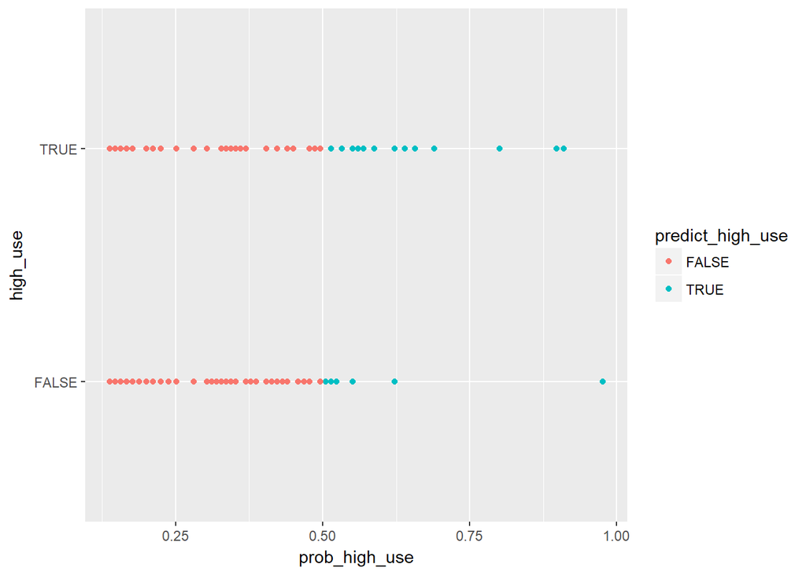

```r
# initialize a plot of 'high_use' versus 'probability' in 'alc'
g <- ggplot(alc, aes(x = prob_high_use, y = high_use, col= predict_high_use))

# define the geom as points and draw the plot
g + geom_point()
```

#The wrong preditctions were quite much

### tabulate the target variable versus the predictions

```r
conf_mat<-table(high_use = alc$high_use, prediction = alc$predict_high_use)
conf_mat<-prop.table(conf_mat)
addmargins(conf_mat)
```

```
##         prediction
## high_use      FALSE       TRUE        Sum
##    FALSE 0.68848168 0.01832461 0.70680628
##    TRUE  0.23298429 0.06020942 0.29319372
##    Sum   0.92146597 0.07853403 1.00000000
```

```r
#Alternatively, this can be done as shown below:
#addmargins(prop.table(table(high_use = alc$high_use, prediction = alc$predict_high_use)))
#table(high_use = alc$high_use, prediction = alc$predict_high_use) %>%  prop.table() %>% addmargins()
```

### mean error of the prediction

```r
mean(abs(alc$high_use-alc$prob_high_use)>0.5)
```

```
## [1] 0.2513089
```

My model has slightly lower error of 0.25 compared with the one on datacamp with 0.26 mean error.

**The below is an alternative way by firstly defining the function to calculate the mean error.**

```r
# define a loss function (mean prediction error)
loss_func <- function(class, prob) {
  n_wrong <- abs(class - prob) > 0.5
  mean(n_wrong)
}
```

```r
# call loss_func to compute the average number of wrong predictions in the (training) data
loss_func(class = alc$high_use, prob = alc$prob_high_use)
```

```
## [1] 0.2513089
```

### K-fold cross-validation

```r
library(boot)
cv <- cv.glm(data = alc, cost = loss_func, glmfit = high_use_mod2, K = 10)

# average number of wrong predictions in the cross validation
cv$delta[1]
```

```
## [1] 0.2565445
```